# A6-Series de tiempo

Esteban Sierra

2025-11-11

# Análisis de tendencia y estacionalidad

```r
anio = c(1,1,1,1,2,2,2,2,3,3,3,3,4,4,4,4)
trimestre = c(1,2,3,4,1,2,3,4,1,2,3,4,1,2,3,4)
ventas = c(4.8, 4.1, 6.0, 6.5, 5.8, 5.2, 6.8, 7.4, 6.0, 5.6, 7.5, 7.8, 6.3, 5.9, 8.0, 8.4)

Datos = data.frame(anio,trimestre,ventas)

serie_de_tiempo_ventas <- ts(
    data = Datos$ventas,
    start = c(Datos$anio[1], Datos$trimestre[1]),
    frequency = 4
)

print(serie_de_tiempo_ventas)
```

```
##   Qtr1 Qtr2 Qtr3 Qtr4
## 1  4.8  4.1  6.0  6.5
## 2  5.8  5.2  6.8  7.4
## 3  6.0  5.6  7.5  7.8
## 4  6.3  5.9  8.0  8.4
```

## Identifica si es una serie estacionaria

La prueba de fuller cuenta con las siguienes hipótesis $H_0=$ La serie no es estacionaria $H_1=$ La serie es estacionaria

```r
library(tseries)
```

```r
library(ggplot2)

adf_test_result <- adf.test(serie_de_tiempo_ventas)

print(adf_test_result)
```

```
##
##  Augmented Dickey-Fuller Test
##
## data:  serie_de_tiempo_ventas
## Dickey-Fuller = -2.7111, Lag order = 2, p-value = 0.3015
## alternative hypothesis: stationary
```

$H_0$ = La serie NO es estacionaria. $p$-value ($0.3$) > $\alpha$ ($0.05$). Cuando $p$ es alto, NO se rechaza $H_0$. Conclusión: No rechazamos la hipótesis de que la serie no es estacionaria. Por lo tanto, concluimos que la serie NO es estacionaria.

## Grafica la serie para verificar su tendencia y estacionalidad

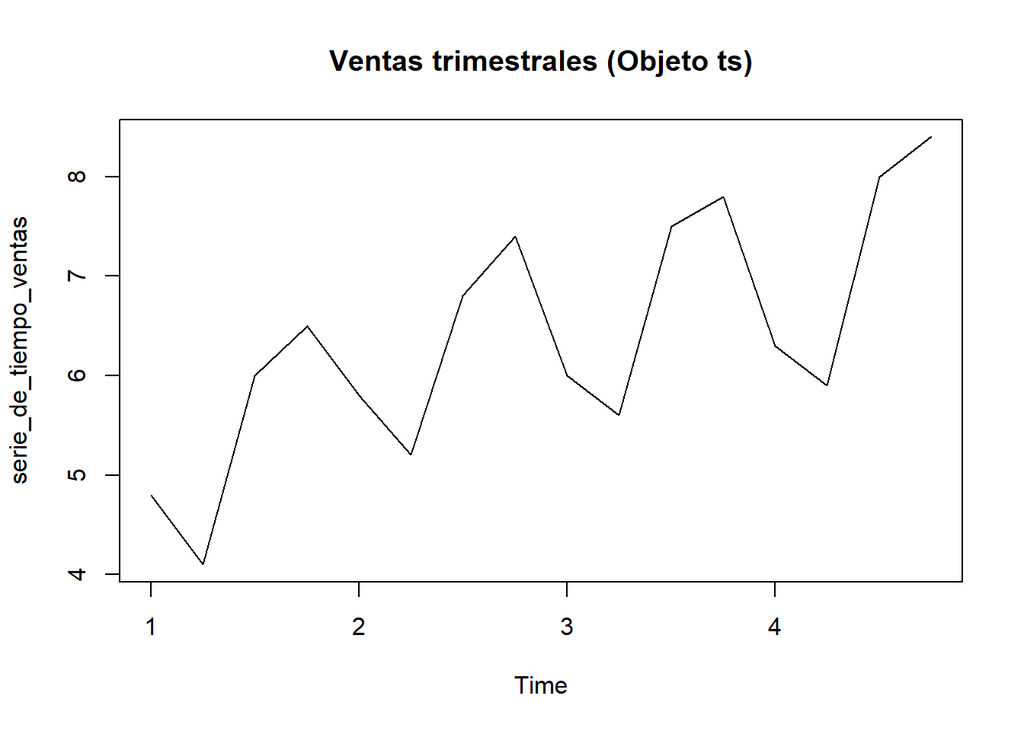

```r
plot(serie_de_tiempo_ventas, main="Ventas trimestrales (Objeto ts)")
```

## Analiza su gráfico de autocorrelación

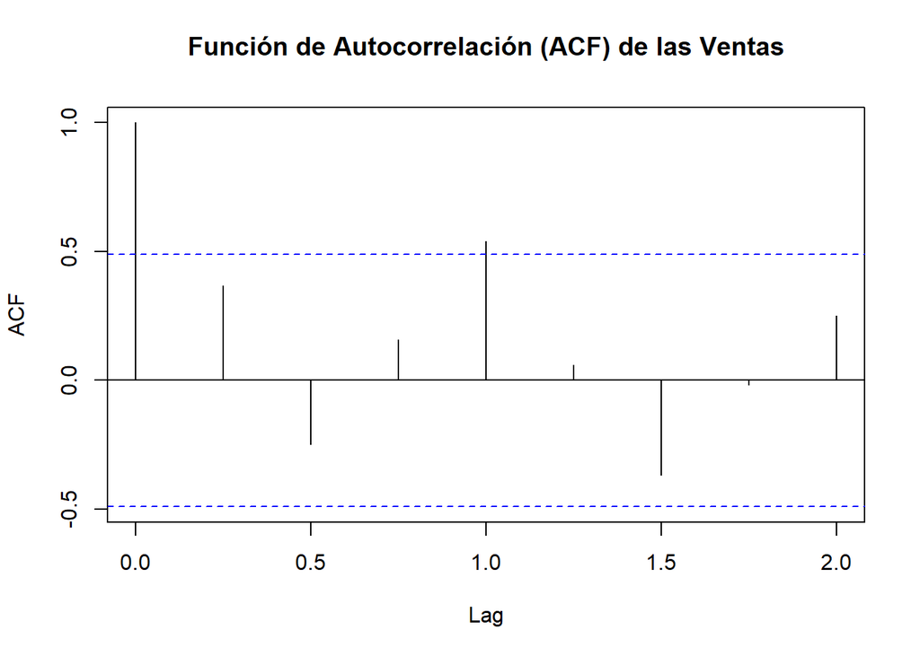

```r
library(stats)

# Graficar la Función de Autocorrelación
acf(serie_de_tiempo_ventas,
    main = "Función de Autocorrelación (ACF) de las Ventas",
    lag.max = 8 # Muestra hasta 8 rezagos (dos años)
)
```

## Identifica si el modelo puede ser sumativo o multiplicativo (puedes probar con ambos para ver con cuál es mejor el modelo)

```r
# Modelo sumativo
modelo_sumativo <- decompose(serie_de_tiempo_ventas)
cat("\nModelo sumativo\n")
```

```
##
## Modelo sumativo
```

```r
#summary(modelo_sumativo)
print(modelo_sumativo)
```

```
## $x
##   Qtr1 Qtr2 Qtr3 Qtr4
## 1  4.8  4.1  6.0  6.5
## 2  5.8  5.2  6.8  7.4
## 3  6.0  5.6  7.5  7.8
## 4  6.3  5.9  8.0  8.4
##
## $seasonal
##         Qtr1       Qtr2       Qtr3       Qtr4
## 1 -0.4395833 -1.0687500  0.5895833  0.9187500
## 2 -0.4395833 -1.0687500  0.5895833  0.9187500
## 3 -0.4395833 -1.0687500  0.5895833  0.9187500
## 4 -0.4395833 -1.0687500  0.5895833  0.9187500
##
## $trend
##     Qtr1   Qtr2   Qtr3   Qtr4
## 1     NA     NA 5.4750 5.7375
## 2 5.9750 6.1875 6.3250 6.4000
## 3 6.5375 6.6750 6.7625 6.8375
## 4 6.9375 7.0750     NA     NA
##
## $random
##          Qtr1        Qtr2        Qtr3        Qtr4
## 1          NA          NA -0.06458333 -0.15625000
## 2  0.26458333  0.08125000 -0.11458333  0.08125000
## 3 -0.09791667 -0.00625000  0.14791667  0.04375000
## 4 -0.19791667 -0.10625000          NA          NA
##
## $figure
## [1] -0.4395833 -1.0687500  0.5895833  0.9187500
##
## $type
## [1] "additive"
##
## attr(,"class")
## [1] "decomposed.ts"
```

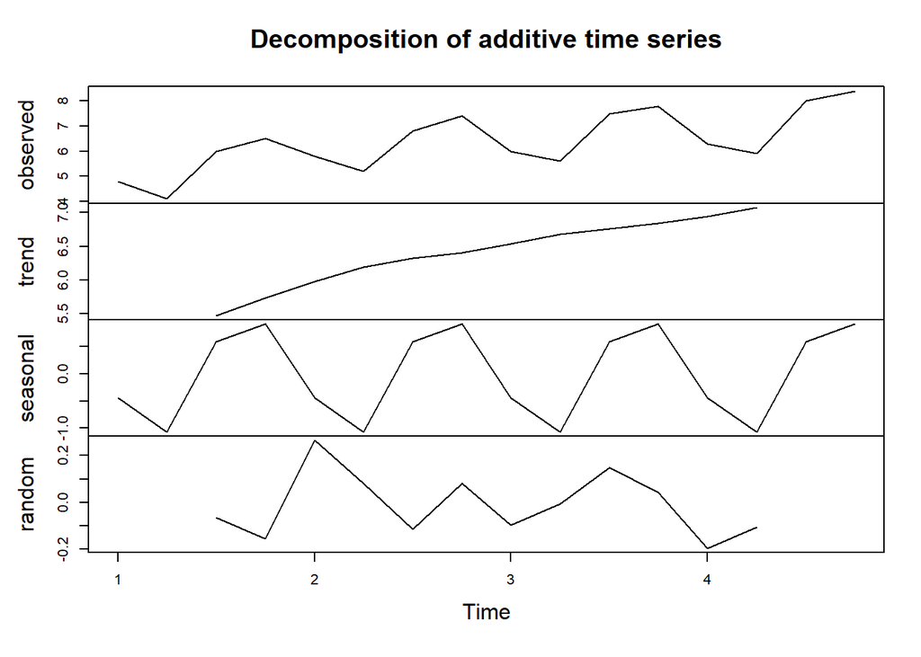

```r
plot(modelo_sumativo)
```

```r
# Modelo multiplicativo
modelo_multiplicativo <- decompose(serie_de_tiempo_ventas, type = "multiplicative")
cat("\nModelo multiplicativo\n")
```

```
##
## Modelo multiplicativo
```

```r
#summary(modelo_multiplicativo)
print(modelo_multiplicativo)
```

```
## $x
##   Qtr1 Qtr2 Qtr3 Qtr4
## 1  4.8  4.1  6.0  6.5
## 2  5.8  5.2  6.8  7.4
## 3  6.0  5.6  7.5  7.8
## 4  6.3  5.9  8.0  8.4
##
## $seasonal
##        Qtr1      Qtr2      Qtr3      Qtr4
## 1 0.9306617 0.8363763 1.0915441 1.1414179
## 2 0.9306617 0.8363763 1.0915441 1.1414179
## 3 0.9306617 0.8363763 1.0915441 1.1414179
## 4 0.9306617 0.8363763 1.0915441 1.1414179
##
## $trend
##     Qtr1   Qtr2   Qtr3   Qtr4
## 1     NA     NA 5.4750 5.7375
## 2 5.9750 6.1875 6.3250 6.4000
## 3 6.5375 6.6750 6.7625 6.8375
## 4 6.9375 7.0750     NA     NA
##
## $random
##        Qtr1      Qtr2      Qtr3      Qtr4
## 1        NA        NA 1.0039818 0.9925353
## 2 1.0430335 1.0048157 0.9849340 1.0129944
## 3 0.9861607 1.0030787 1.0160445 0.9994305
## 4 0.9757661 0.9970658        NA        NA
##
## $figure
## [1] 0.9306617 0.8363763 1.0915441 1.1414179
##
## $type
## [1] "multiplicative"
##
## attr(,"class")
## [1] "decomposed.ts"
```

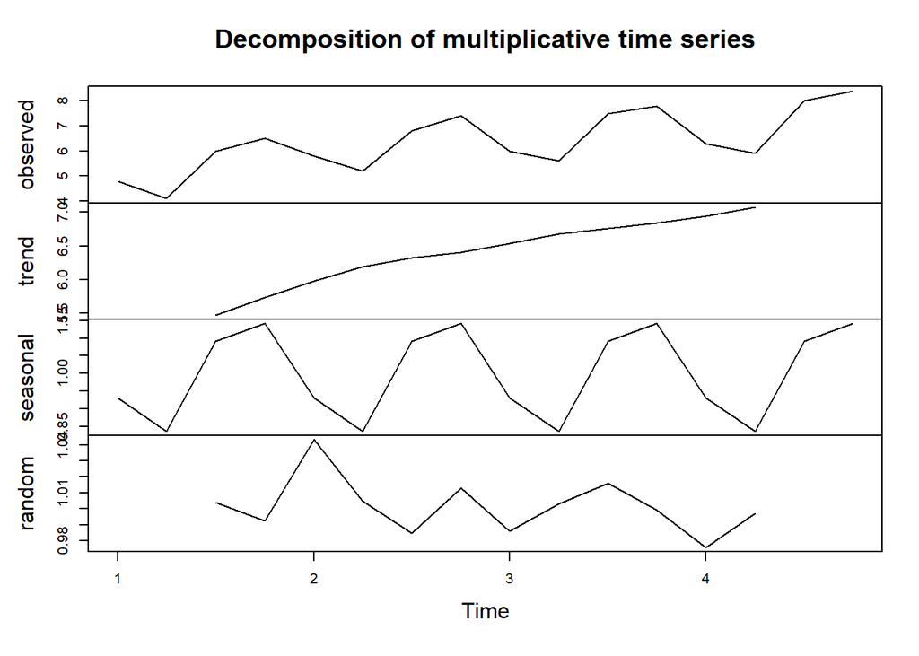

```r
plot(modelo_multiplicativo)
```

# Calcula los índices estacionales

```r
indices_estacionales <- head(modelo_multiplicativo$seasonal, 4)

cat("Índices Estacionales (Multiplicativos):\n")
```

```
## Índices Estacionales (Multiplicativos):
```

```r
print(indices_estacionales)
```

```
##        Qtr1      Qtr2      Qtr3      Qtr4
## 1 0.9306617 0.8363763 1.0915441 1.1414179
```

# Analiza el modelo lineal de la tendencia`

## Realiza la regresión lineal de la tendencia (ventas desestacionalizadas vs tiempo)

```r
# --- ANÁLISIS DEL MODELO LINEAL DE LA TENDENCIA ---

# 1. Calcular la serie desestacionalizada (Original / Estacional)
#    Y = T * S * R  =>  Deseasonalized (T*R) = Y / S
#    Esto tendrá NAs al inicio y al final, heredados de la tendencia.
serie_desest_mult <- serie_de_tiempo_ventas / modelo_multiplicativo$seasonal

# 2. Graficar la serie desestacionalizada
plot(serie_desest_mult,
     main="Serie Desestacionalizada (Original / Estacional)",
     ylab="Ventas Desestacionalizadas (T*R)",
     col="blue")

# 3. Preparar datos para la regresión (Manejo de NAs)
tiempo <- 1:length(serie_desest_mult) # Vector de tiempo (1 a 16)

# 4. Alineación de datos (ELIMINA EL ERROR)
#    Encontramos los índices donde la serie desestacionalizada NO es NA
indices_validos <- which(!is.na(serie_desest_mult))

#    Creamos vectores alineados (longitud 12, en este caso)
tiempo_alineado <- tiempo[indices_validos]
ventas_desest_alineadas <- serie_desest_mult[indices_validos]

# 5. Crear el dataframe para la regresión
datos_regresion <- data.frame(
     Tiempo = tiempo_alineado,
     Ventas_Desest = ventas_desest_alineadas
)

# 6. Ajustar el modelo de tendencia lineal
modelo_tendencia_lineal <- lm(Ventas_Desest ~ Tiempo, data = datos_regresion)

summary(modelo_tendencia_lineal)
```

```
##
## Call:
## lm(formula = Ventas_Desest ~ Tiempo, data = datos_regresion)
##
## Residuals:
##     Min      1Q  Median      3Q     Max
## -0.5007 -0.1001  0.0037  0.1207  0.3872
##
## Coefficients:
##             Estimate Std. Error t value Pr(>|t|)
## (Intercept)  5.10804    0.11171   45.73  < 2e-16 ***
## Tiempo       0.14738    0.01155   12.76 4.25e-09 ***
## ---
## Signif. codes:  0 '***' 0.001 '**' 0.01 '*' 0.05 '.' 0.1 ' ' 1
##
## Residual standard error: 0.213 on 14 degrees of freedom
## Multiple R-squared:  0.9208, Adjusted R-squared:  0.9151
## F-statistic: 162.7 on 1 and 14 DF,  p-value: 4.248e-09
```

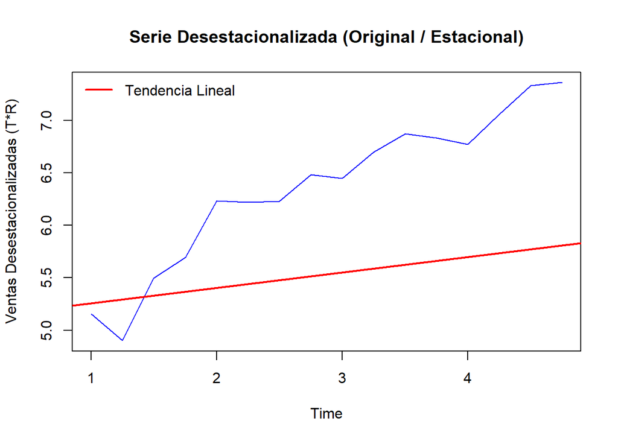

```r
# 7. Graficar la línea de tendencia sobre la serie desestacionalizada
#    'abline' superpone la línea de regresión en el gráfico existente
abline(modelo_tendencia_lineal, col="red", lwd=2)
legend("topleft", legend="Tendencia Lineal", col="red", lwd=2, bty="n")
```

```r
#summary(modelo_multiplicativo)
print(modelo_multiplicativo)
```

```
## $x
##   Qtr1 Qtr2 Qtr3 Qtr4
## 1  4.8  4.1  6.0  6.5
## 2  5.8  5.2  6.8  7.4
## 3  6.0  5.6  7.5  7.8
## 4  6.3  5.9  8.0  8.4
##
## $seasonal
##        Qtr1      Qtr2      Qtr3      Qtr4
## 1 0.9306617 0.8363763 1.0915441 1.1414179
## 2 0.9306617 0.8363763 1.0915441 1.1414179
## 3 0.9306617 0.8363763 1.0915441 1.1414179
## 4 0.9306617 0.8363763 1.0915441 1.1414179
##
## $trend
##     Qtr1   Qtr2   Qtr3   Qtr4
## 1     NA     NA 5.4750 5.7375
## 2 5.9750 6.1875 6.3250 6.4000
## 3 6.5375 6.6750 6.7625 6.8375
## 4 6.9375 7.0750     NA     NA
##
## $random
##        Qtr1      Qtr2      Qtr3      Qtr4
## 1        NA        NA 1.0039818 0.9925353
## 2 1.0430335 1.0048157 0.9849340 1.0129944
## 3 0.9861607 1.0030787 1.0160445 0.9994305
## 4 0.9757661 0.9970658        NA        NA
##
## $figure
## [1] 0.9306617 0.8363763 1.0915441 1.1414179
##
## $type
## [1] "multiplicative"
##
## attr(,"class")
## [1] "decomposed.ts"
```

En base a los valores de estacionalidad:

Qtr1: 0.9306617 Cuatrimestre bajo Qtr2: 0.8363763 Cuatrimestre muy bajo Qtr3: 1.0915441 Cuatrimestre alto Qtr 4: 1.1414179 Cuatrimestre muy alto